# 13 · Introducción al Web Scraping

## Introducción al Web Scraping

13 · WEB · DIAGNÓSTICO DE FUENTES

Introducción al  
Web Scraping

**Cómo localizar y validar datos de una web**

HTML, DOM y evidencia para auditoría.

Sesión de 90 minutos · Portal de aula simulado

## Mapa de la sesión · 90 minutos

| Minutos | Parte | Pregunta |
| --- | --- | --- |
| 0–10 | Fuente y alcance | ¿Qué dato merece extraerse? |
| 10–20 | De HTTP al DOM | ¿Qué recibe y construye el navegador? |
| 20–45 | Lectura de HTML | ¿Qué elementos representan los datos? |
| 45–65 | Selectores y cardinalidad | ¿Cómo se localizan y verifican? |
| 65–80 | Diagnóstico y calidad | ¿Cómo cambia el contenido y qué evidencia queda? |
| 80–90 | Demostración docente y cierre | ¿Qué técnica se justifica? |

## Apertura · «Lo veo en la web»

En el navegador aparecen dos avisos. Un programa descarga la página y encuentra una tabla sin filas. ¿Qué evidencia explicaría esa diferencia?

| Hipótesis | Evidencia para comprobarla |
| --- | --- |
| El filtro no tiene resultados | La página declara un estado vacío |
| La página aún no ha cargado los datos | Aparece una petición posterior |
| Se recibió una pantalla alternativa | El cuerpo muestra acceso o mantenimiento |

## Caso de aula · Observatorio de auditoría

El equipo sigue un **portal simulado de avisos públicos** para detectar novedades que podrían requerir una revisión documental.

| Campo mínimo | Uso |
| --- | --- |
| Identificador del aviso | Comparar publicaciones sin depender del título |
| Fecha publicada | Ordenar la revisión y delimitar la ventana |
| Título | Orientar la lectura |
| URL de origen | Recuperar la publicación y verificarla |

**Entregable del bloque.** Diagnóstico de la fuente y criterio de cobertura.

## Definir el objeto de observación

| Decisión | Ejemplo del Observatorio |
| --- | --- |
| Unidad | Un aviso, identificado por su ID |
| Universo | Avisos de la sección y ventana acordadas |
| Frecuencia | Una revisión diaria de aula |
| Novedad | ID nuevo o contenido relevante cambiado |
| Exclusiones | Borradores, contenido privado, datos innecesarios |

## Scraping, crawling y automatización web

| Concepto | Acción dominante | Ejemplo |
| --- | --- | --- |
| Scraping | Recuperar datos de páginas | Obtener los campos de un aviso |
| Crawling | Descubrir y recorrer URLs | Enumerar secciones y páginas de avisos |
| Automatización web | Interactuar con una interfaz | Pulsar «Cargar avisos» y esperar un resultado |

La recopilación puede usar más de una de estas técnicas.

## Dónde buscar la fuente primero

| Fuente disponible | Señal a favor | Pregunta pendiente |
| --- | --- | --- |
| API oficial o exportación | Formato estructurado y contrato publicado | ¿Cubre campos y periodo? |
| HTML inicial | Dato visible en la respuesta del documento | ¿La estructura se mantiene? |
| Datos servidos tras la carga | Una respuesta posterior contiene el dato | ¿Su consumo directo está autorizado? |
| Interfaz con interacción | El estado final requiere un flujo de UI | ¿Puede automatizarse de forma autorizada? |

## 2 · De la URL a lo que vemos

| Etapa | Qué ocurre | Qué se puede inspeccionar |
| --- | --- | --- |
| Navegación | El navegador solicita un documento | URL, método, estado, tipo |
| Interpretación | Analiza HTML y crea el DOM | Estructura de nodos |
| Recursos | Carga CSS, imágenes y scripts | Peticiones y dependencias |
| Ejecución | JavaScript puede pedir datos y mutar el DOM | Fetch/XHR y cambios en Elements |
| Renderizado | El navegador presenta un estado visual | Resultado visible y su contexto |

## URL, ruta, consulta y fragmento

```
https://portal.example/avisos?anio=2026&pagina=2#resultados
```

| Componente | Papel en el diagnóstico |
| --- | --- |
| Esquema y autoridad | Identificar el origen de la solicitud |
| Ruta | Elegir recurso o sección |
| Consulta | Transportar filtros o paginación si la aplicación los admite |
| Fragmento | Referencia interpretada en el cliente |

## Cabeceras que cambian la interpretación

| Elemento | Qué aclara |
| --- | --- |
| Content-Type | Si el cuerpo es HTML, JSON u otro formato |
| charset | Cómo convertir bytes en texto cuando se declara |
| Location | Adónde apunta una redirección |
| Retry-After | Cuándo reintentar si el proveedor lo indica |
| Cache-Control | Qué restricciones de reutilización indica el servidor |

## Leer los estados HTTP con contexto

| Estado | Hipótesis inicial | Qué hacer |
| --- | --- | --- |
| 200 | El servidor completó la petición | Validar el cuerpo y la sección |
| 3xx | Redirección o respuesta condicional | Revisar estado, destino o caché |
| 401 / 403 | Credencial necesaria o acceso rechazado | Detener y verificar el canal autorizado |
| 404 | Ruta ausente o no expuesta | Revisar URL y fuente |
| 429 / 5xx | Límite o incidencia | Respetar la política de espera y presupuesto |

## Cuatro respuestas 200, cuatro resultados

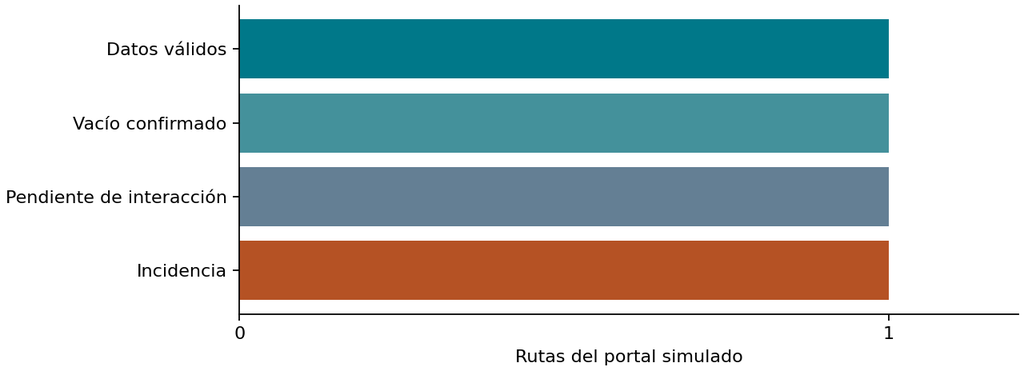

El portal devuelve una ruta con datos, una con vacío confirmado, una pendiente de interacción y una de incidencia.

**Universo del gráfico** · cuatro rutas diseñadas para la clase. Cada una representa una categoría distinta.

## HTML · El documento completo

```html
<!doctype html>
<html lang="es">
  <head><meta charset="utf-8"><title>Avisos</title></head>
  <body><main><h1>Avisos publicados</h1></main></body>
</html>
```

**Qué observar.** `head` describe el documento. `body` reúne su contenido. Dentro de `body`, `main` ayuda a ubicar la sección de interés.

## HTML · Etiqueta, elemento y atributo

```html
<a class="detalle" href="/avisos/av-101">Ver aviso</a>
```

| Pieza | En el ejemplo | Pregunta |
| --- | --- | --- |
| Etiqueta inicial | `<a …>` | ¿Qué tipo de elemento abre? |
| Atributos | `class`, `href` | ¿Qué metadatos añade? |
| Contenido | `Ver aviso` | ¿Qué información contiene? |
| Etiqueta final | `</a>` | ¿Dónde termina? |

## HTML · De anidación a árbol

[figure not shown]

Árbol con main como raíz del fragmento. Contiene article; article contiene h2 y a; a contiene el texto Ver aviso.

**Lectura.** `article` es hijo de `main`. `a` es descendiente de `main` y hermano de `h2`.

## HTML · Qué representa un registro

```html
<article class="aviso destacado" data-id="AV-101">
  <h2>Actualización de criterios</h2>
  <time datetime="2026-10-12">12 de octubre</time>
  <a class="detalle" href="/avisos/av-101">Ver aviso</a>
</article>
```

**Regla de lectura.** Localiza el elemento que agrupa el registro y luego identifica los campos dentro de él.

## HTML · Semántica y atributos de negocio

| Marcado | Información que aporta | Cómo usarla |
| --- | --- | --- |
| `<article>` | Unidad de contenido | Delimitar una tarjeta |
| `<time datetime="…">` | Fecha normalizada | Leer atributo y validar |
| `data-id="AV-101"` | Identificador de la fuente | Comprobar unicidad y persistencia |
| `class="aviso destacado"` | Dos tokens de clase | Determinar si describen diseño o función |

## HTML · Texto literal, texto del nodo y vista

```html
<h2>Control&nbsp;&amp; <strong>revisión</strong></h2>
```

| Lectura | Qué esperar |
| --- | --- |
| HTML | Entidades y etiquetas |
| Texto del nodo y sus descendientes | «Control & revisión» |
| Vista | El navegador aplica estilos y reglas de visibilidad |

**Criterio.** Normaliza espacios con una regla explícita y conserva el valor original cuando sea relevante.

## HTML · Enlaces relativos y absolutos

| Atributo `href` | Con base `https://portal.example/avisos/index.html` |
| --- | --- |
| `detalle.html` | `https://portal.example/avisos/detalle.html` |
| `/detalle.html` | `https://portal.example/detalle.html` |
| `#resumen` | El mismo documento con fragmento |
| `https://otro.example/info` | Otro origen |

## HTML · Leer una tabla por su estructura

```html
<table id="avisos">
  <thead><tr><th>ID</th><th>Fecha</th></tr></thead>
  <tbody><tr><td>AV-101</td><td>2026-10-12</td></tr></tbody>
</table>
```

**Correspondencia.** `table` delimita el conjunto. `tr` delimita la fila. `th` identifica una cabecera y `td` una celda de datos.

## HTML · Cuando una tabla parece rectangular

| Señal | Riesgo de interpretación |
| --- | --- |
| `colspan` o `rowspan` | Una celda visual cubre varias posiciones |
| Fila de subtotal | Se cuenta como un aviso |
| Cabecera repetida | Entra como fila de datos |
| Tabla dentro de otra | Se mezclan filas de distintos niveles |
| Celda omitida | Se desplaza la asignación de campos |

## HTML · Cuando el parser completa el marcado

```html
<table id="avisos"><tr><td>AV-101</td></tr></table>
```

Al inspeccionar el DOM del navegador, puede aparecer una estructura `table → tbody → tr → td`.

Una ruta de nodos copiada del navegador puede depender de la estructura que construyó su parser.

## HTML · Estructura de un aviso

```html
<tr data-aviso="AV-101">
  <td>AV-101</td>
  <td><time datetime="2026-10-12">12 de octubre</time></td>
  <td>Actualización de criterios de control</td>
</tr>
```

Una fila agrupa los campos del mismo aviso. Un atributo semántico puede aportar una representación estable del valor.

## HTML recibido, DOM actual y vista

| Representación | Qué conserva | Dónde observarla |
| --- | --- | --- |
| HTML de respuesta | Documento devuelto en esa petición | Network → Doc → Response |
| DOM actual | Árbol en memoria, con cambios posteriores | Elements |
| Vista | Lo visible para el usuario en ese estado | Página |

El HTML inicial puede contener un marcador vacío que el navegador rellena más tarde.

## Selectores · Qué resuelve un selector CSS

Un selector formula una **pregunta de coincidencia sobre elementos**. Los campos se leen después de localizar esos elementos.

| Pregunta | Selector |
| --- | --- |
| ¿Dónde están las tarjetas? | `article.aviso` |
| ¿Cuál corresponde a este identificador? | `article[data-id="AV-101"]` |
| ¿Dónde está el enlace del aviso? | `article.aviso a[href]` |

## Selectores · Tipo, ID, clase y atributo

| Selector | Coincide con |
| --- | --- |
| `article` | Elementos de ese tipo |
| `#avisos` | Elemento cuyo id es avisos |
| `.aviso` | Elementos con el token de clase aviso |
| `[data-id]` | Elementos que tienen ese atributo |
| `[data-id="AV-101"]` | Elementos con ese valor exacto |

## Selectores · Combinar sin espacios

| Expresión | Lectura |
| --- | --- |
| `article.aviso` | El mismo elemento es article y tiene clase aviso |
| `.aviso.destacado` | El mismo elemento tiene ambos tokens |
| `.aviso .destacado` | Un descendiente tiene clase destacado |
| `h2, h3` | Selección de elementos h2 o h3 |

## Selectores · Descendiente e hijo directo

```html
<article class="aviso">
  <div><a href="/avisos/av-101">Ver aviso</a></div>
</article>
```

| Selector | Resultado |
| --- | --- |
| `article.aviso a` | Encuentra el enlace |
| `article.aviso > a` | Cero coincidencias |

## Selectores · Acotar el ámbito

| Patrón | Posible problema |
| --- | --- |
| `a[href]` en todo el documento | Mezcla navegación, pie y detalles |
| `main a[href]` | Aún puede captar ayuda y filtros |
| `article.aviso a.detalle[href]` | Relaciona el enlace con su función |
| Buscar dentro de un registro identificado | Mantiene unidos sus campos |

## Selectores · La cardinalidad forma parte del contrato

| Campo | Cardinalidad esperada | Caso a investigar |
| --- | --- | --- |
| Tarjetas | 0 a muchas | Cero sin señal de vacío |
| Identificador | 1 por tarjeta | ID ausente o duplicado |
| Fecha | 0 o 1 según contrato | Más de una fecha sin distinguir su papel |
| Documentos adjuntos | 0 a muchos | Enlaces de navegación mezclados |

## Selectores · Posición y fragilidad

| Regla | Supuesto implícito |
| --- | --- |
| `td:nth-child(2)` | La fecha sigue siendo el segundo hijo elemento |
| `td[data-campo="fecha"]` | El productor mantiene el atributo semántico |
| `main > div > div > table` | Se mantiene la estructura de contenedores |
| `article.aviso time[datetime]` | Se mantiene el contrato semántico de la tarjeta |

## Selectores · Diseñar para detectar cambios

Si cambia «Actualizado» por «Fecha de publicación», ¿el proceso debería seguir publicando el dato en la misma columna?

**Antes.** El selector encuentra una celda y el código la acepta.

**Después.** El control comprueba cabecera, cardinalidad y formato. Si el significado ha cambiado, deriva el caso a revisión.

## Demostración · Disección de un aviso

| Campo | Elemento candidato | Valor esperado |
| --- | --- | --- |
| ID | `article[data-id]` | Atributo `data-id` |
| Título | `h2` dentro de la tarjeta | Texto |
| Fecha | `time[datetime]` dentro de la tarjeta | Atributo `datetime` |
| Destino | `a.detalle[href]` dentro de la tarjeta | URL resuelta a partir de `href` |

**Pregunta.** ¿Qué campos siguen disponibles si una tarjeta no publica su fecha?

## Estático, dinámico e híbrido

| Escenario | Antes de interactuar | Después |
| --- | --- | --- |
| HTML con filas | Datos en la respuesta inicial | Pueden mantenerse visibles |
| Contenedor sin filas | Plantilla inicial | JS obtiene datos y añade filas |
| Híbrido | Primer lote en HTML | Filtros o siguientes lotes piden datos |

**Unidad de diagnóstico.** El campo y la acción que interesan.

## Captura · Antes de pulsar

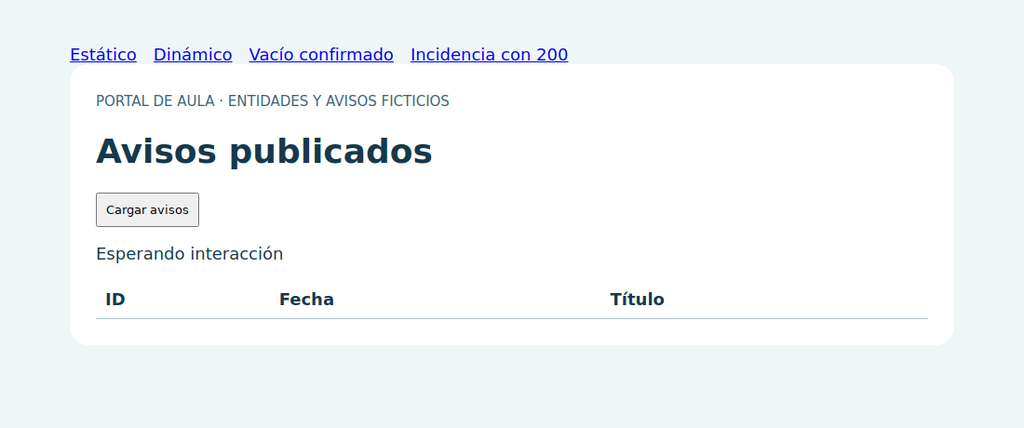

Portal de aula con la tabla vacía y el estado Esperando interacción.

La cabecera existe. El estado indica que falta una acción.

## Captura · Después de pulsar

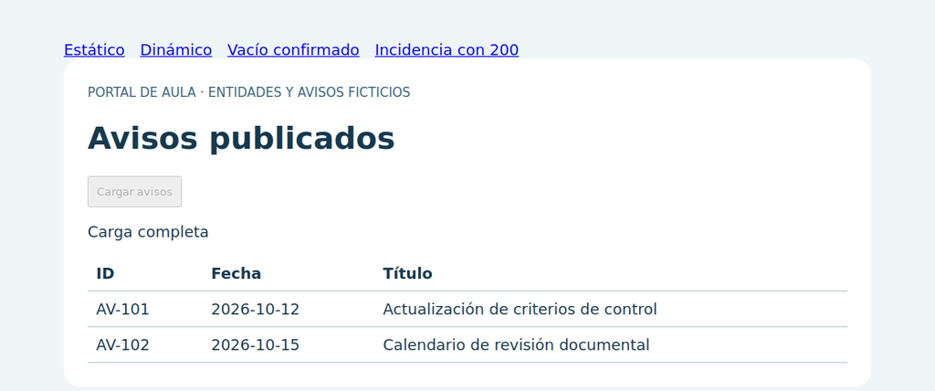

Portal de aula con dos avisos y estado Carga completa.

Aparecen AV-101 y AV-102. Network registra una respuesta de `/datos.json`.

## GIF · El viaje de los avisos

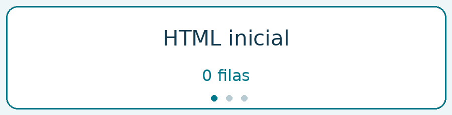

El HTML inicial trae cero filas, el JSON aporta dos registros y el DOM muestra dos filas tras la carga.

**Doc → acción → Fetch → DOM actualizado.**

## 3 · DevTools · Una inspección reproducible

| Paso | Evidencia |
| --- | --- |
| Abrir Network y recargar | Peticiones de navegación y recursos |
| Seleccionar el documento principal | Estado, tipo y respuesta HTML |
| Buscar el ID AV-101 en Response | Presencia o ausencia en ese cuerpo |
| Pulsar «Cargar avisos» y filtrar Fetch/XHR | Petición inducida por la acción |
| Comparar Response con Elements | Dato transferido y DOM actualizado |

## Qué revela cada vista de Network

| Vista | Pregunta |
| --- | --- |
| Headers | ¿Qué URL, método y estado tuvo? |
| Payload | ¿Qué filtros o datos se enviaron? |
| Response | ¿Qué contenido devolvió el servidor? |
| Initiator | ¿Qué documento o script inició la petición? |
| Timing | ¿En qué fases se consumió tiempo? |

## Mini diagnóstico · ¿Dónde buscarías?

| Situación | Primera comprobación |
| --- | --- |
| El título figura en la página y en Response | Verificar que pertenece al bloque de datos correcto |
| El ID aparece en un JSON incrustado en el HTML | Confirmar que el dato se puede interpretar y usar |
| El ID aparece solo tras pulsar | Examinar petición posterior y estado final |
| El ID solo figura dentro de un iframe | Identificar el documento y sus condiciones de acceso |

## Cómo elegir el enfoque del próximo bloque

| Evidencia | Enfoque a evaluar |
| --- | --- |
| Hay API documentada y suficiente | Consumo de API, bloque 12 |
| Las filas están en el documento | Extracción HTML, bloque 14 |
| La interacción autorizada produce el estado requerido | Navegador automatizado, bloque 15 |
| Faltan permiso o estabilidad para operar | Resolver acceso o buscar otra fuente |

## 4 · Condiciones de acceso y uso

Antes de automatizar una fuente, concretar **qué acceso existe, qué uso está autorizado y qué datos necesita el control**.

| Capa | Pregunta |
| --- | --- |
| Acceso técnico | ¿Qué recursos devuelve el sitio y con qué condiciones? |
| Reglas de rastreo | ¿Qué directivas publica para clientes automáticos? |
| Uso y autorización | ¿Qué alcance permiten la fuente y el procedimiento interno? |
| Minimización | ¿Qué campos bastan y cómo se conservarán? |

## Leer robots.txt

```
User-agent: *
Disallow: /interno/
```

| Señal | Interpretación en aula |
| --- | --- |
| User-agent | Identifica el grupo de clientes al que se aplican reglas |
| Disallow | Señala una ruta que el grupo debe evitar |
| Acceso técnico y autorización | Se comprueban por separado |

## Presupuesto de peticiones

Sea $P$ el número de páginas, $d$ el número de detalles por página y $F$ el número de ejecuciones.

$$N_{base}=F\,P\,(1+d)$$

**Ejemplo.** 2 ejecuciones × 10 páginas × (1 listado + 5 detalles) = 120 peticiones base.

## 5 · Cobertura y estados de extracción

| Estado del lote | Evidencia mínima | Publicación |
| --- | --- | --- |
| Datos válidos | Campos y comprobaciones correctas | Publicar con cobertura registrada |
| Vacío confirmado | Señal explícita y universo comprobado | Publicar cero con contexto |
| Pendiente | Interacción o carga aún incompleta | Marcar pendiente |
| Incidencia | Cuerpo alternativo, acceso o red | Señalar fallo |
| Parcial | Quedan páginas o registros por validar | Indicar cobertura parcial |

## Paginación y límites del universo

| Patrón | Riesgo para la cobertura |
| --- | --- |
| Enlace «Siguiente» | Parar demasiado pronto o entrar en bucle |
| Número de página | Movimiento de filas entre páginas |
| Botón «Cargar más» | Confundir pausa con fin |
| Scroll con lista virtual | Ver solo una parte de las filas en el DOM |

**Controles.** Criterio de parada, límite de recorrido, IDs únicos y total de referencia si existe.

## Tres controles antes de guardar

| Nivel | Ejemplo válido | Fallo detectable |
| --- | --- | --- |
| Transporte | Estado 200 y tipo esperado | Ruta errónea o formato alternativo |
| Estructura | Sección y campos esperados | Marcado cambiado |
| Dominio | ID único y fecha válida | Duplicados o fecha imposible |

La estructura puede cambiar mientras el sitio sigue mostrando una página visualmente parecida.

## Indicadores · Denominadores explícitos

$$\text{Cobertura}=\frac{\text{IDs únicos observados}}{\text{IDs esperados en el mismo universo}}$$

$$\text{Completitud de fecha}=\frac{\text{registros con fecha válida}}{\text{registros observados}}$$

**Ejemplo.** Se observan 7 de 10 avisos y 6 tienen fecha válida. Cobertura 70 %. Completitud de fecha 85,7 %.

## Evidencia y trazabilidad

| Guardar si procede | Qué permite revisar |
| --- | --- |
| URL, filtros e instante UTC | Alcance y momento |
| Estado, tipo, recuentos y diagnóstico | Resultado de la extracción |
| Copia o huella de los bytes | Comparación con la evidencia conservada |
| Versión de reglas y claves de deduplicación | Reproducir una decisión |

## Comparar capturas con claves estables

| Momento 1 | Momento 2 | Resultado candidato |
| --- | --- | --- |
| AV-101 título A | AV-101 título A | Sin cambio |
| AV-102 título B | AV-102 título C | Modificación |
| — | AV-103 título D | Alta |
| AV-104 título E | — | Ausencia por investigar |

## 6 · Demostración docente · Del HTML a la decisión

| Qué muestro | Qué debe observar el grupo |
| --- | --- |
| Respuesta de /estatico | Los IDs ya están en el documento |
| Respuesta de /dinamico | Hay estructura, pero faltan las filas |
| Clic en «Cargar avisos» | Una respuesta JSON aporta los datos |
| Elements después del clic | El DOM contiene dos filas |
| Vacío y mantenimiento | El mismo código 200 admite diagnósticos distintos |

## Modelo de diagnóstico del Observatorio

| Pregunta | Respuesta de aula |
| --- | --- |
| ¿Qué buscábamos? | ID, fecha y título de los avisos |
| ¿Dónde aparece el dato? | HTML de /estatico o JSON posterior de /dinamico |
| ¿Qué observamos en el DOM? | Dos filas después de pulsar |
| ¿Qué rutas requieren tratamiento distinto? | Vacío explícito y mantenimiento |
| ¿Qué evidencia conservaríamos? | Ruta, estado, tipo, hora, condición y recuento |

## Qué se implementará en los bloques siguientes

| Bloque | Punto de partida | Trabajo práctico |
| --- | --- | --- |
| 14 · Extracción HTML | Documento con registros disponibles | Seleccionar, extraer, normalizar y validar |
| 15 · Selenium | Estado que se alcanza al interactuar | Navegar, interactuar, esperar y verificar |

El notebook reúne ejemplos y diez ejercicios para consulta o repaso posterior.

## Cierre · 5 minutos

1. ¿Qué comprobarías si ves dos filas en Elements y ninguna en Response?
2. ¿Qué evidencia permitiría afirmar que un filtro devolvió cero avisos?
3. ¿Cuándo pasarías a extracción HTML y cuándo a Selenium?

**Salida esperada.** Una decisión técnica acompañada de evidencia y condiciones de uso.

## Ampliación · Qué conserva la codificación

```
bytes → texto Unicode → árbol → campos
```

| Señal | Interpretación |
| --- | --- |
| «revisiÃ³n» | Posible decodificación incompatible |
| Espacios diferentes | Comparación literal que puede fallar |
| `&amp;` en la respuesta | Entidad que el parser interpreta |

## Ampliación · Cuatro sentidos de «falta el dato»

| Observación | Tratamiento |
| --- | --- |
| No hay nodo fecha | Campo ausente |
| Hay nodo sin contenido | Campo vacío |
| Contenido «31/02/2026» | Valor inválido |
| Campo aparece tras un clic | Pendiente de interacción |

## Ampliación · JSON incrustado y atributos

```html
<script type="application/json" id="estado">
{"avisos":[{"id":"AV-101"}]}
</script>
```

Un documento puede transportar un dato estructurado sin representarlo como una fila del DOM visible.

## Ampliación · Cuando el dato vive en otro contexto

| Representación | Qué observar |
| --- | --- |
| `iframe` | Documento y origen propios |
| Shadow DOM | Árbol asociado a un componente |
| `canvas` | Píxeles dibujados |
| PDF enlazado | Recurso con formato propio |

## Ampliación · Depurar una regla con tres muestras

| Muestra | Qué comprueba |
| --- | --- |
| Dos avisos con todos sus campos | Ruta normal y cardinalidad |
| Un aviso sin fecha | Ausencia dentro del registro |
| Página de mantenimiento | Pantalla alternativa y parada |

**Salida esperada.** Un recuento y un diagnóstico que expliquen qué representación se observó.

## Ampliación · De registros a evidencia

| Etapa | Ejemplo |
| --- | --- |
| Localizar | Tarjetas dentro de la sección de avisos |
| Leer | Texto, `datetime` y `href` |
| Normalizar | Fecha ISO y URL absoluta |
| Validar | ID único y campo obligatorio presente |
| Conservar | Origen, hora UTC y regla aplicada |

## Referencias

- [Chrome DevTools · Inspección de actividad de red](https://developer.chrome.com/docs/devtools/network/)
- [MDN · Introducción al DOM](https://developer.mozilla.org/en-US/docs/Web/API/Document_Object_Model/Introduction)
- [MDN · Selectores y combinadores CSS](https://developer.mozilla.org/en-US/docs/Web/CSS/Guides/Selectors/Selectors_and_combinators)
- [RFC 9110 · Semántica HTTP](https://www.rfc-editor.org/rfc/rfc9110)
- [RFC 9309 · Robots Exclusion Protocol](https://www.rfc-editor.org/rfc/rfc9309)
- [EUR-Lex · Reglamento (UE) 2016/679](https://eur-lex.europa.eu/eli/reg/2016/679/oj)

**Notas docentes · N para cerrar**